# Oxfam America Website Content

##### Report last updated on July 10, 2019 at 03:45 PM

## Oxfam Website Content Summary

##### The following report is for the period between 2019-06-01 and 2019-07-09.

Effective 2019-06-01 we established a new metric for reporting website content engagement - Qualified Page Views.  
For immersive stories a qualified page view is counted if any of the following happen:  
1) a user spends 45 or more seconds on a page and scrolls through at least 50% of the page  
2) a user spends 45 or more seconds on a page and views at least 50% of any audio or video elements on the page or  
3) a user clicks a CTA.

For non-immersive stories a qualified page view is counted if any of the following happen:  
1) a user spends 30 or more seconds on a page and scrolls through at least 50% of the page  
2) a user spends 30 or more seconds on a page and views at least 50% of any audio or video elements on the page or  
3) a user clicks a CTA.

Unique Page Views are the total number of unique page views for any given piece of content.  
Qualified Page View Rate is the number of Qualified Page Views divided by the number of Unique Page Views and is expressed as a percentage.

| Content | Type | Unique Page Views | Unique Qualified Page Views | CTA Clicks | Qualified Page View Rate |
| --- | --- | --- | --- | --- | --- |
| www.oxfamamerica.org/explore/stories/whats-really-going-on-at-the-us-mexico-southern-border/ | oa stories | 3,537 | 1,603 | 0 | 45.32% |
| www.oxfamamerica.org/explore/stories/whats-the-difference-between-sudan-and-south-sudan/ | oa stories | 3,086 | 1,065 | 0 | 34.51% |
| politicsofpoverty.oxfamamerica.org/2019/02/6-simple-reasons-we-should-raise-the-minimum-wage/ | politics of poverty blog | 2,249 | 1,151 | 0 | 51.18% |
| www.oxfamamerica.org/explore/stories/what-is-famine-and-how-can-we-stop-it/ | oa stories | 1,749 | 679 | 0 | 38.82% |
| firstperson.oxfamamerica.org/2013/03/10-everyday-food-brands-and-the-few-giant-companies-that-own-them/ | first person blog | 1,692 | 376 | 0 | 22.22% |
| www.oxfamamerica.org/explore/stories/what-is-ebola/ | oa stories | 1,169 | 475 | 0 | 40.63% |
| firstperson.oxfamamerica.org/2018/11/six-ways-to-fix-up-a-well-and-get-clean-water/ | first person blog | 960 | 149 | 0 | 15.52% |
| www.oxfamamerica.org/explore/stories/these-10-companies-make-a-lot-of-the-food-we-buy-heres-how-we-made-them-better/ | oa stories | 924 | 129 | 0 | 13.96% |
| politicsofpoverty.oxfamamerica.org/2015/01/poor-versus-low-income-what-term-should-we-use/ | politics of poverty blog | 906 | 89 | 0 | 9.82% |
| www.oxfamamerica.org/explore/stories/top-10-things-you-need-to-know-about-oxfam/ | oa stories | 903 | 391 | 0 | 43.30% |

[output cut: 1834 more lines]

# Dataset Summary Statistics

| Summary Stat | Unique Page Views | Unique Qualified Page Views | CTA Clicks | Qualified Page View Rate |
| --- | --- | --- | --- | --- |
| Min. | 1 | 0 | 0 | 0% |
| 1st Qu. | 1 | 0 | 0 | 0% |
| Median | 2 | 1 | 0 | 25% |
| Mean | 20 | 7 | 0 | 32% |
| 3rd Qu. | 6 | 2 | 0 | 50% |
| Max. | 3537 | 1603 | 62 | 133% |

# Top Performing Content

##### Content in the 99th percentile for either total page views or qualified page views for the period between 2019-06-01 and 2019-07-09.

• The 99th percentile threshold for total unique page views was 286.  
• The 99th percentile threshold for unique qualified page views was 106.

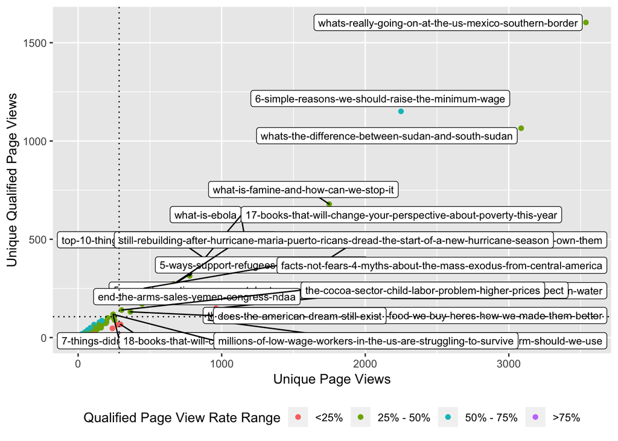

# Daily Total and Qualified Unique Page Views

##### Daily counts for the period between 2019-06-01 and 2019-07-09.

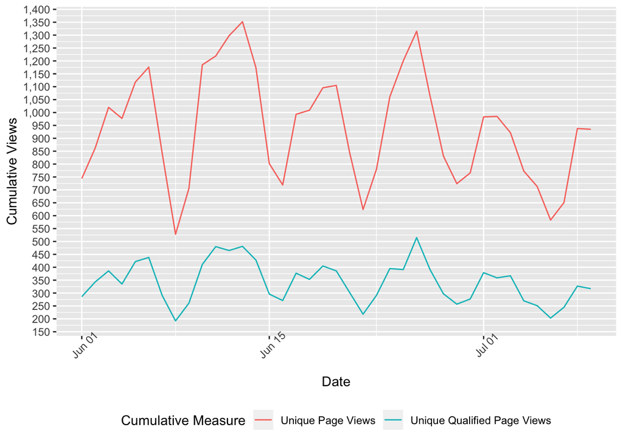

# Average Qualified Page View Rate

##### Daily average for the period between 2019-06-01 and 2019-07-09.

• Ratio of unique qualified page views to total unique page views in aggregate for content in this report by day.

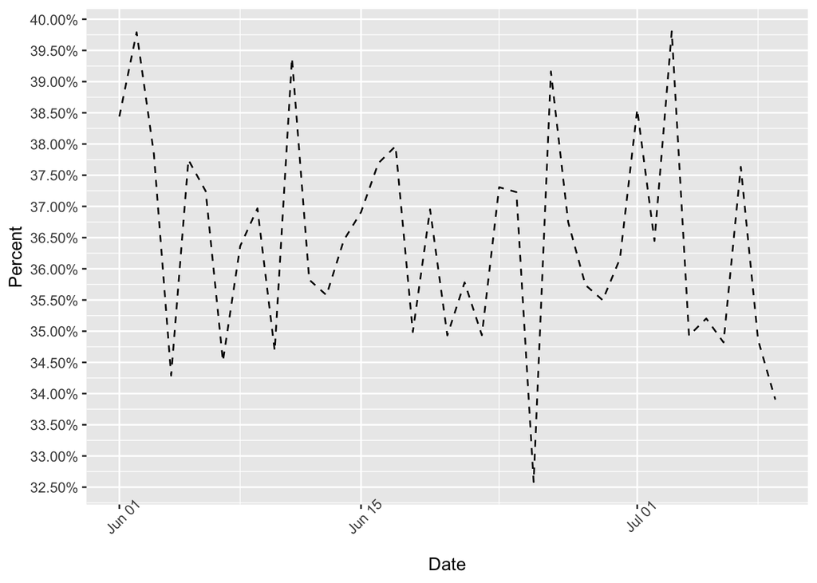

# Cumulative Total and Qualified Unique Page Views

##### Cumulative totals for the period between 2019-06-01 and 2019-07-09.

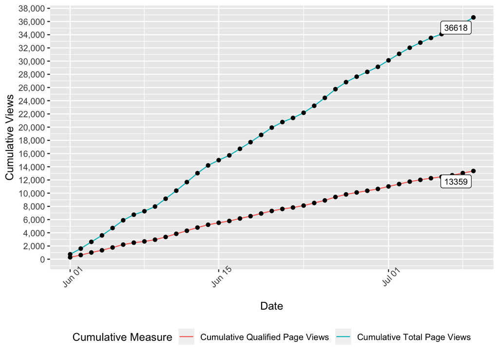

# Unique Qualified Page Views - By Device

##### unique qualified page views for the period between 2019-06-01 and 2019-07-09.

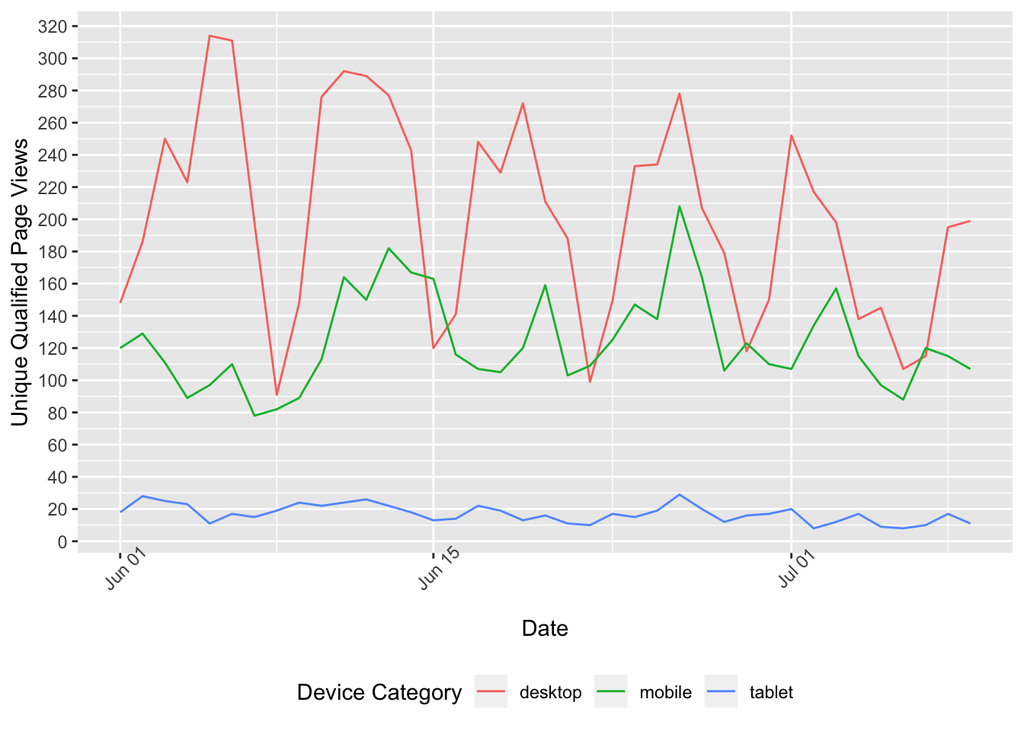

# Average Qualified Page View Rate - By Device

##### Daily average for the period between 2019-06-01 and 2019-07-09.

• Ratio of unique qualified page views to total unique page views in aggregate for content in this report by day.

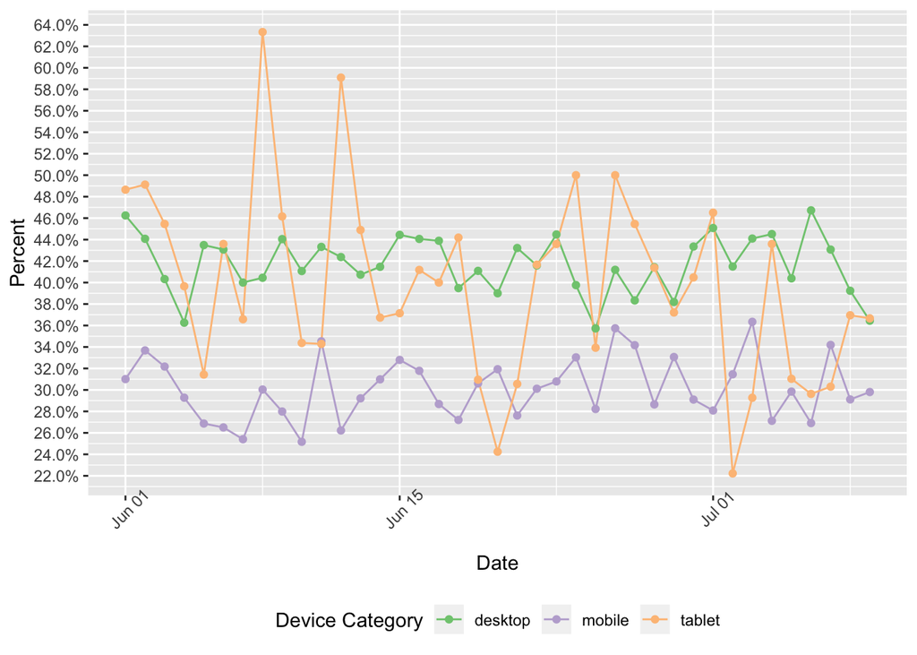

## Oxfam Website Content Summary - By Device Category

##### Period between 2019-06-01 and 2019-07-09.

| Device Category | Unique Page Views | Unique Qualified Page Views | CTA Clicks | Avg Qualified Page View Rate |
| --- | --- | --- | --- | --- |
| desktop | 18,999 | 7,868 | 74 | 41.41% |
| mobile | 15,939 | 4,824 | 22 | 30.27% |
| tablet | 1,680 | 667 | 5 | 39.70% |

## Oxfam Website Content Summary - By Source / Medium

##### Period between 2019-06-01 and 2019-07-09.

| Source / Medium | Unique Page Views | Unique Qualified Page Views | CTA Clicks | Avg Qualified Page View Rate |
| --- | --- | --- | --- | --- |
| google / organic | 27,295 | 10,222 | 24 | 37.45% |
| (direct) / (none) | 3,498 | 952 | 9 | 27.22% |
| google-grant / cpc | 1,167 | 473 | 0 | 40.53% |
| bing / organic | 607 | 241 | 0 | 39.70% |
| oxfam.org / referral | 570 | 235 | 13 | 41.23% |
| m.facebook.com / referral | 521 | 149 | 3 | 28.60% |
| t.co / referral | 292 | 137 | 4 | 46.92% |
| FY20_eNews_June / email | 223 | 83 | 15 | 37.22% |
| yahoo / organic | 207 | 95 | 0 | 45.89% |
| FY20_ImpactReport_June_2 / email | 201 | 36 | 0 | 17.91% |

[output cut: 350 more lines]

## Additional Resources

[Total Page Views](https://analytics.google.com/analytics/web/#/report/content-pages/a229991w56373875p60454320/_u.date00=20190601&_u.date01=20190603)  
Qualified Page Views  
Content CTAs  
* Note that qualified page views and content CTA tracking is available starting 2019-06-01.